# lab

**Convex and Distributed Optimization Lab**  
**MSIAM — Université Grenoble Alpes — 2018/2019**  
**Lecturers: Jérôme Malick, Yassine Laguel, Sélim Chraibi**

**Author: Raha RAZAVI

```python
# Automatic reload of local libraries
%load_ext autoreload
%autoreload 2
%reload_ext autoreload
%matplotlib inline
```

```
The autoreload extension is already loaded. To reload it, use:
  %reload_ext autoreload
```

> **I. Introduction**  
> **II. The optimization problem**  
> **III. Implementing the solvers**  
> GD (Gradient descent))  
> SGD (Stochastic Gradient Descent))  
> SAGA (Stochastic Average Gradient "Amélioré"))  
> SVRG (Stochastic Variance Reduced Gradient))  
> Comparison  
> **IV. Regularization**  
> **V. Further development**

In this lab, you will implement optimization algorithms that you've studied in class and use them to fit a logistic regression classification model.

You will be implementing a simplified version of [`sklearn.linear_model.LogisticRegression`](https://scikit-learn.org/stable/modules/generated/sklearn.linear_model.LogisticRegression.html).

Part of the work has already been done for you (see the `\lib` folder), so you'll only have to implement the `##### TODO (i) #####` sections of the code. Whenever you complete such a section, we ask you to **copy it in this notebook**. We want you to **only send us a pdf or html export of this notebook** so we won't be able to see your work if it's not in this notebook.

Report in groups of 1 to 3 students.  
**Due date:** Monday, January 6, 2019 (before midnight).  
**Send to:** cdo.grenoble@gmail.com

# I. Introduction

We consider the [Student Performance](http://archive.ics.uci.edu/ml/datasets/Student+Performance) dataset. This dataset contains student demographic, social, school-related features, how many classes they've missed, etc.

The goal we give ourselves is to predict whether a student will pass (final grade > 12).

We denote $A \in \mathcal{M}_{n,d}(\mathbb{R})$ the feature matrix, containing $n$ samples with $d$ features, and $b \in \{-1,1\}^n$ the label vector where $-1$ encodes `fail` and $1$ encodes `pass`.

The data has already been preprocessed (yay less work for you 🎉). You can check `\lib\datasets.py` if you're curious, otherwise, you can just use the following to load your dataset:

```python
from lib.datasets import load_student_data

A_train, A_test, b_train, b_test = load_student_data('data/student-mat.csv', split=0.25)
```

As mentioned previously, you're going to implement a simplified version of [`sklearn.linear_model.LogisticRegression`](https://scikit-learn.org/stable/modules/generated/sklearn.linear_model.LogisticRegression.html). So let's first see what the finished product should look like.

**Question:**

- Import [sklearn.linear_model.LogisticRegression](https://scikit-learn.org/stable/modules/generated/sklearn.linear_model.LogisticRegression.html) .
- Create an instance of sklearn's logistic regression classifiers with SAGA as its solver.
- Fit the classifier on the training data and compute the score of the fitted model on the test set.

```python
from sklearn.linear_model import LogisticRegression

lr = LogisticRegression(solver='saga', max_iter=400)
lr.fit(A_train, b_train)
score = lr.score(A_test, b_test)
print(score)
```

```
0.8888888888888888
```

# II. The optimization problem

Logistic regression consists in finding the parameter $x \in \mathbb{R}^d$ that best fits: $$ b_i = \begin{cases} \phantom{-}1 \ \textrm{ if }\ \langle a_{i}, x\rangle \ge 0 \\ -1 \ \textrm{ if }\ \langle a_{i}, x\rangle < 0 \end{cases} $$ for all the samples $i$ of the training set (where $a_i$ is the $i^{th}$ line of $A$ and $b_i$ the $i^{th}$ element of $b$). To measure this fit, logistic regression chooses the following loss:

$$ \textrm{LogisticLoss}(b_i, \left\langle a_{i}, x\right\rangle ) = \log \left(1+\exp \left(-b_{i}\left\langle a_{i}, x\right\rangle\right)\right) $$

The corresponding optimization problem we will consider is the following:

Minimization of the empirical risk $f$ of the $L_2$-regularized logistic regression model, on the dataset $(A_{\textrm{train}},b_{\textrm{train}})$: $$ \begin{aligned} \textrm{min}_{x\in \mathbb{R}^d} \ f(x) \ &= \ \textrm{min}_{x\in \mathbb{R}^d} \ \frac{1}{n_{\textrm{train}}} \sum_{i=1}^{n_{\textrm{train}}} f_i(x) \\ &= \ \textrm{min}_{x\in \mathbb{R}^d}\frac{1}{n_{\textrm{train}}} \sum_{i=1}^{n_{\textrm{train}}} \textrm{LogisticLoss}(b_i, \left\langle a_{i}, x\right\rangle ) + \frac{l_2}{2}\|x\|^{2}_2, \end{aligned} $$ where $l_2 \ge 0$ is the $L_2$ regularization coefficient.

To simplify the notation, we'll stop indexing $A$, $b$ and $n$ with "$\textrm{train}$" in the following.

**Question:** $f$ is $\mu$-strongly convex.

- Give a lower bound on $\mu$.
- Complete **TODO (1)** in **\lib\linear_model.py**.

> **Answer:** Since we have $f = g(x) + \frac{l_2}{2}||x||_2^2$ where g(x) is a convex function which is written above. The definition for f $\mu$ -strongly convex is the minimum $\mu$ convex we can take from the function f still remains convex. Mathematically: $f - \frac{\mu}{2}||x||_2^2$ remains convex. We can conclude $\mu$ should be $l_2$ Which makes sense because $l_2$ is positive.

**Question:** Denote $\lambda_{\max}$ the largest eigenvalue of the real symmetric matrix $AA^T$.

- Prove that $\lambda_{\max}(\nabla^2 f_i) \le \lambda_{\max}(\frac{a_i a_i^T}{4} + l_2 I_d)$
- Prove that $\lambda_{\max}(a_i a_i^T) \le \|a_i\|^2_2$

> **Answer:** For the first question: Let us first compute the $∇^2𝑓_𝑖$: since $f_i(x)=LogisticLoss(𝑏𝑖,⟨𝑎𝑖,𝑥⟩)=log(1+exp(−𝑏_𝑖⟨𝑎_𝑖,𝑥⟩))$ we have: $\frac{\partial f_i}{\partial x_j}(x) = \frac{-b_ia_{ij}exp(−𝑏_𝑖⟨𝑎_𝑖,𝑥⟩)}{1+exp(−𝑏_𝑖⟨𝑎_𝑖,𝑥⟩)} = \frac{-b_ia_{ij}}{1+exp(𝑏_𝑖⟨𝑎_𝑖,𝑥⟩)}$

> Therefore we can obtain: $\frac{\partial ^2 f_i}{\partial x_j\partial x_k}(x) = \frac{b_i^2a_{ij}a_{ik}exp(−𝑏_𝑖⟨𝑎_𝑖,𝑥⟩)}{(1+exp(−𝑏_𝑖⟨𝑎_𝑖,𝑥⟩))^2} = \frac{a_{ij}a_{ik}exp(−𝑏_𝑖⟨𝑎_𝑖,𝑥⟩)}{(1+exp(−𝑏_𝑖⟨𝑎_𝑖,𝑥⟩))^2} $ (the reason of the last eqaulity is $b_i^2$=1)

> By a very simple reasoning we can conclude taht $−𝑏_𝑖⟨𝑎_𝑖,𝑥⟩<0$, Thus $0<exp(−𝑏_𝑖⟨𝑎_𝑖,𝑥⟩)≤1$, Then $0<\frac{exp(−𝑏_𝑖⟨𝑎_𝑖,𝑥⟩)}{(1+exp(−𝑏_𝑖⟨𝑎_𝑖,𝑥⟩))^2}≤ 1/4$ and finally we have the following inequalities: $\frac{a_{ij}a_{ik}exp(−𝑏_𝑖⟨𝑎_𝑖,𝑥⟩)}{(1+exp(−𝑏_𝑖⟨𝑎_𝑖,𝑥⟩))^2}≤\frac{a_{ij}a_{ik}exp(−𝑏_𝑖⟨𝑎_𝑖,𝑥⟩)}{(1+exp(−𝑏_𝑖⟨𝑎_𝑖,𝑥⟩))^2} + l_2≤ \frac{a_{ij}a_{ik}}{4} + l_2$

> means for any i we have $∇^2𝑓_𝑖 ≤\frac{a_{ij}a_{ik}}{4}+𝑙_2𝐼_𝑑$ it is correct elementwise therefore we have the result.

> For the second question:

> We should asumme $a_i$ is a column of the matrix $A$ and it is $n*1$ and we have $||a_i||_2^2 = ∑_{j=1}^n a_{ji}^2$

> As we know the matrix $a_ia_i^T$ will have the form

> $\begin{bmatrix} a_{1i}^2 & a_{1i}a_{2i} \cdots & a_{1i}a_{ni} \\ a_{2i}a_{1i} & a_{2i}^2 \cdots & a_{2i}a_{ni} \\ \vdots & \ddots & \vdots \\ a_{ni}a_{1i} & a_{ni}a_{2i} \cdots & a_{ni}^2 \end{bmatrix}$

> From the matrix $trace(a_ia_i^T)= ∑_{j=1}^n a_{ji}^2$ which is equal to $||a_i||_2^2 = ∑_{j=1}^n a_{ji}^2$

> We know that $trace(a_ia_i^T)= ∑_{j=1}^m \lambda _i = \lambda _{max} +(∑_{j=1}^m \lambda _i - \lambda _{max}) = ||a_i||_2^2 $

> Egienvalues of the matrix are all non-negative since $AA^T$ is symetric can be decomposed and its eigenvalues are the singular values of the matrix $A$ which are non-negative thus $(∑_{j=1}^m \lambda _i - \lambda _{max})$ is non-negative and we can get our result: $ \lambda _{max} ≤ \lambda _{max} +(∑_{j=1}^m \lambda _i - \lambda _{max}) = ||a_i||_2^2$

A consequence of these results is that the $f_i$s and $f$ are all $L$-smooth with $L \le \frac{\max_i\|a_i\|^2_2}{4} + l_2$ and we can therefore use the following value in our implementation:

```
L = 0.25 * max(np.linalg.norm(A,2,axis=1))**2 + self.l2
```

# III. Implementing the solvers

To implement gradient methods, we need an oracle that will compute both batch gradients $\nabla f$ and partial gradients $\nabla f_i$.

**Question:** In the code below, $\nabla f$ has already been implemented.

- Complete **TODO (2)** bellow.
- Add your code to **\lib\linear_model.py**.

```python
def grad(x, i=None):
    '''
    Gradient of the objective function at x.
    If no i is given, grad should return the batch gradient.
    Otherwise, it should return the partial gradient associated the the datapoint (A[i], b[i]).
    '''

    if i is None: # return batch gradient
        output = -b/(1 + np.exp(b*np.dot(A, x)))
        output = sum(np.diag(output))/n @ A
        output += self.l2*x
    else: # return partial gradient associated the datapoint (A[i], b[i])
        ######## TODO (2) ########
         output = (-b[i]*A[i])/(1+np.exp(b[i]*(np.dot(A[i], x))))
        #pass
    return output
```

# GD (Gradient descent)

At iteration k of the GD algorithm, the following update is executed:

$$ x_{k+1} \leftarrow x_{k} - \gamma\nabla f(x_k) $$

**Question:**

- What stepsize $\gamma$ ensures the convergence of this algorithm and under what assumptions?
- Complete **TODO (3)** and **TODO (4)**
- Add your code to **\lib\solvers.py**.

> **Answer:** Suppose the function $f : R^n → R$ is convex and differentiable, and that its gradient is Lipschitz continuous with constant $L > 0$, i.e. we have that $||∇f(x) − ∇f(y)||_2 ≤ L||x − y||_2$ for any x, y. Then if we run gradient descent for k iterations with a fixed step size $t ≤ 1/L$, it will yield a solution $f^k$ which satisfies: $f(x^k) - f(x^{*}) ≤ \frac{||x^0 - x^ {*}||_2^2}{2 \gamma k}$ where $f(x^{*})$ is the optimal value. Intuitively, this means that gradient descent is guaranteed to converge and that it converges with rate $O(1/k)$.

```python
def GD(x0, grad, max_iter, n, L, mu):
    '''
    Parameters
    ----------
    x0: array, shape (nb_features,)
        Initialisation of the solver
    grad: function
        Gradient of the objective function
    max_iter: int
        Number of iterations (i.e. number of descent steps). Note that for GD or SVRG,
        one iteration is one epoch i.e, one pass through the data, while for SGD, SAG and SAGA,
        one iteration uses only one data point.
    n: int
        Dataset size
    L: float
        Smoothness constant of the objective function
    mu: float
        Strong convexity constant of the objective function

    Returns
    -------
    x: array, shape (nb_features,)
        final iterate of the solver
    x_tab: array, shape (nb_features, max_iter)
        table of all the iterates
    '''
    stepsize  = 1/L ######## TODO (3) ########
    x         = x0
    x_tab     = np.copy(x)

    for k in range(max_iter):
        x     =  x - stepsize*grad(x, i=None) ######## TODO (4): Implement a single step ########
        x_tab = np.vstack((x_tab, x))

    return x, x_tab
```

**Question:** Run the code below to test your code.

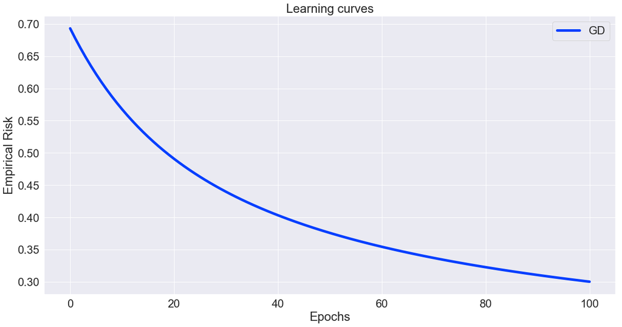

```python
from lib.linear_model import LogisticRegression
from lib.visuals import learning_curve

clf_gd = LogisticRegression(solver='gd', l2=0.01, max_iter=100)
clf_gd.fit(A_train, b_train)

learning_curve(GD=clf_gd)
```

# SGD (Stochastic Gradient Descent)

At iteration k of the SGD algorithm, the following update is executed:

$$ \begin{cases} i \textrm{ chosen randomly in } \{1...n\}\\ x_{k+1} \leftarrow x_{k} - \gamma_k \nabla f_i(x_k) \\ \end{cases} $$

**Question:**

- What stepsize $\gamma_k$ ensures the convergence of this algorithm and under what assumptions?
- Complete **TODO (5)**
- Add your code to **\lib\solvers.py**.

```python
import random
def SGD(x0, grad, max_iter, n, L, mu):
    stepsize  = 1
    x         = x0
    x_tab     = np.copy(x)
    # choosing i_k randomly in {1,..., n}
    #i_k = random.randint(1 , n)
    for k in range(1, max_iter + 1):
        ######## TODO (5) ########
        i_k = random.randint(0 , n-1)
        stepsize = 1/k
        x = x - stepsize*grad(x, i_k)
        if k%n == 0: # each completed epoch
            x_tab = np.vstack((x_tab, x))
    return x, x_tab
```

**Question:** Run the code below to test your code.

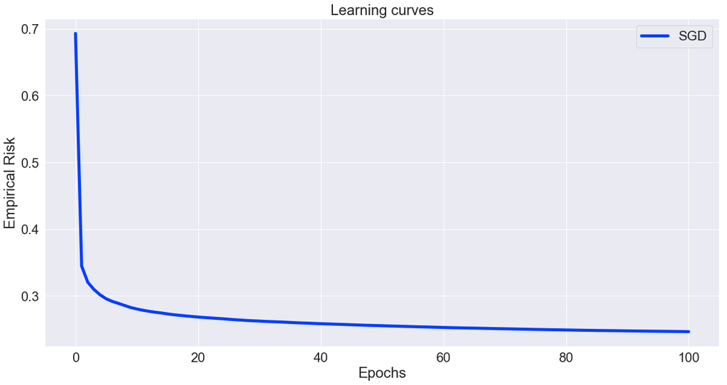

```python
clf_sgd = LogisticRegression(solver='sgd', l2=0.01, max_iter=100*len(b_train))
clf_sgd.fit(A_train, b_train)

learning_curve(SGD=clf_sgd)
```

# SAGA (Stochastic Average Gradient "Amélioré")

SAGA starts by computing a single batch gradient, then at iteration k, the following update is executed:

$$ \begin{cases} i \textrm{ chosen randomly in } \{1...n\}\\ x_{k+1} \leftarrow x_{k} - \gamma_k\big(\nabla f_i(x_k) - \alpha_i + \bar{\alpha}\big) \\ \alpha_i \leftarrow \nabla f_i(x) \end{cases} $$

where $(\alpha_j)_{j=1}^n$ are gradients evaluated at previous iterates and $\bar{\alpha}=\frac{1}{n}\sum^n_{j=1}\alpha_j$.

**Question:**

- What stepsize $\gamma_k$ ensures the convergence of this algorithm and under what assumptions?
- Complete **TODO (6)**
- Add your code to **\lib\solvers.py**.

```python
import random
def SAGA(x0, grad, max_iter, n, L, mu):
    ######## TODO (6) ########
    stepsize  = 1
    x         = x0
    x_tab     = np.copy(x)
    alpha = 0
    # choosing l randomly in {1,..., n}
    l = random.randint(0, n-1)
    alpha_l = grad(x, l)
    for  j in range(n):
        alpha += grad(x, j)
    alpha = alpha/n
    for k in range(1, max_iter + 1):
        ######## TODO (6) ########
        # choosing l randomly in {1,..., n}
        l = random.randint(0, n-1)
        stepsize = 1/k

        x = x - stepsize*(grad(x, l) - alpha_l + alpha)
        alpha_l = grad(x, l)
        for  j in range(n):
            alpha += grad(x , j)
        alpha = alpha/n
        if k%n == 0: # each completed epoch
            x_tab = np.vstack((x_tab, x))


    return x, x_tab
```

**Question:** Run the code below to test your code.

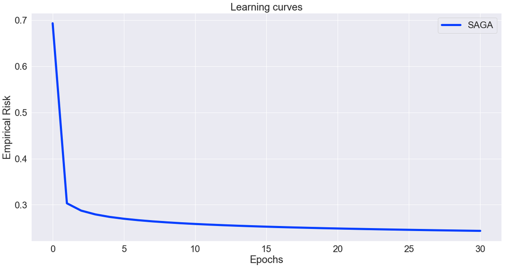

```python
clf_saga = LogisticRegression(solver='saga', l2=0.01, max_iter=30*len(b_train))
clf_saga.fit(A_train, b_train)

learning_curve(SAGA=clf_saga)
```

# SVRG (Stochastic Variance Reduced Gradient)

At iteration k of the SVRG algorithm, we perform the following:

$$ \begin{cases} \textrm{Compute the batch gradient } \nabla f(x_k)\\ \textrm{Initialise }y_0 = x_k\\ \textrm{for m in 0...M-1: } \begin{cases} i \textrm{ chosen randomly in } \{1...n\} \\ y_{m+1} \leftarrow y_{m} - \gamma_k\big(\nabla f_i(y_m) - \nabla f_i(x_k) + \nabla f(x_k)) \end{cases}\\ x_{k+1} \leftarrow y_{M} \end{cases} $$

**Question:**

- What stepsize $\gamma_k$ ensures the convergence of this algorithm and under what assumptions?
- Complete **TODO (7)**
- Add your code to **\lib\solvers.py**.

```python
def SVRG(x0, grad, max_iter, n, L, mu):
    ######## TODO (7) ########
    stepsize  = 1
    x         = x0
    x_tab     = np.copy(x)
    b_grad = 0
    M = 2*n
    for k in range(1, max_iter + 1):
        ######## TODO (7) ########
        stepsize = 1/k
        b_grad = grad(x, i=None)
        y = x
        for m in range(0, M-1):
            # choosing l randomly in {1,..., n}
            l = random.randint(0, n-1)
            y = y - (stepsize*(grad(y, l) - grad(x, l) + b_grad))
        x = y

        x_tab = np.vstack((x_tab, x))

    return x, x_tab
```

**Question:** Run the code below to test your code.

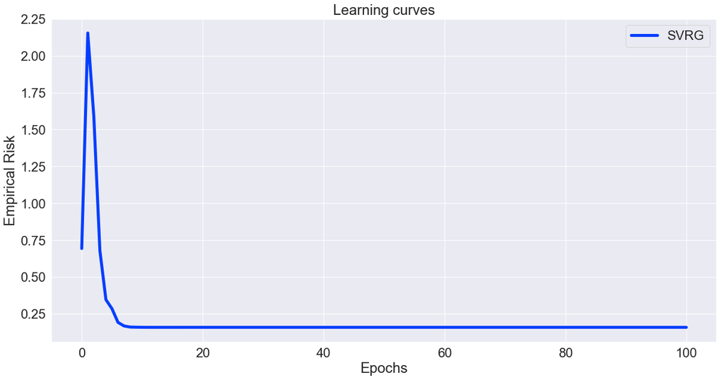

```python
clf_svrg = LogisticRegression(solver='svrg', l2=0.01, max_iter=100)
clf_svrg.fit(A_train, b_train)

learning_curve(SVRG=clf_svrg)
```

# Comparison

**Question:** Run the code below to compare all the methods you've implemented.

```python
epochs = 50
n = len(b_train)

clf_gd   = LogisticRegression(solver='gd', l2=0.01, max_iter=epochs)
clf_sgd  = LogisticRegression(solver='sgd', l2=0.01, max_iter=epochs*n)
clf_saga = LogisticRegression(solver='saga', l2=0.01, max_iter=epochs*n)
clf_svrg = LogisticRegression(solver='svrg', l2=0.01, max_iter=epochs)

clf_gd.fit(A_train, b_train)
clf_sgd.fit(A_train, b_train)
clf_saga.fit(A_train, b_train)
clf_svrg.fit(A_train, b_train)
```

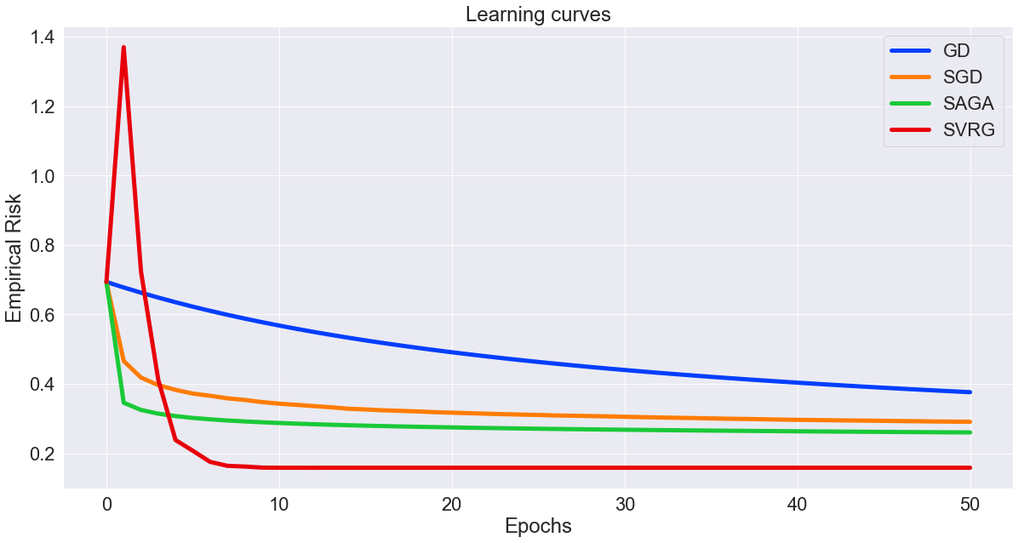

```
gd:	Accuracy on training set: 91.2%
	Accuracy on testing set:  81.8%
sgd:	Accuracy on training set: 87.8%
	Accuracy on testing set:  89.9%
saga:	Accuracy on training set: 89.9%
	Accuracy on testing set:  80.8%
svrg:	Accuracy on training set: 95.3%
	Accuracy on testing set:  88.9%
```

```python
learning_curve(GD=clf_gd, SGD=clf_sgd, SAGA=clf_saga, SVRG=clf_svrg)

for clf, name in zip([clf_gd, clf_sgd, clf_saga, clf_svrg], ['gd', 'sgd', 'saga', 'svrg']):
    print(name + ':' \
          + "\tAccuracy on training set: {0:0.1f}%".format(100*clf.score(A_train, b_train)))
    print("\tAccuracy on testing set:  {0:0.1f}%".format(100*clf.score(A_test, b_test)))
```

# IV. Regularization

**Question:**

- Rewrite the empirical risk minimization objective with both $L_1$ and $L_2$ regularization (with coefficients $l_1$ and $l_2$).
- Is this objective $\mu$-strongly convex, $L$-smooth, differentiable?
- Complete the **TODO (8)** to account for the new term in the objective.
- Add your code to **lib/linear_model.py**.

> **Answer:** Minimization of the empirical risk $f$ of the $L_1$ and $L_2$-regularized logistic regression model, on the dataset $(A_{\textrm{train}},b_{\textrm{train}})$:

$$ \begin{aligned} \textrm{min}_{x\in \mathbb{R}^d} \ f(x) \ &= \ \textrm{min}_{x\in \mathbb{R}^d} \ \frac{1}{n_{\textrm{train}}} \sum_{i=1}^{n_{\textrm{train}}} f_i(x) \\ &= \ \textrm{min}_{x\in \mathbb{R}^d}\frac{1}{n_{\textrm{train}}} \sum_{i=1}^{n_{\textrm{train}}} \textrm{LogisticLoss}(b_i, \left\langle a_{i}, x\right\rangle ) + l_1\|x\|_1 + \frac{l_2}{2}\|x\|^{2}_2, \end{aligned} $$

> where $l_2 \ge 0$ is the $L_2$ regularization coefficient and $l_1 \ge 0$ is the $L_1$ regularization coefficient.

> It can be written that f still is a convex function since norm-1 and norm-2 are both convex. Using the definition of $\mu$-strongly convexity of a function, considering $g(x) = f(x) - \frac{l_2}{2}\|x\|^{2}_2$ is still convex so this new f is $l_2$-strongly convex. f is not differentiable everywhere since norm-1 is not differentiable at zero, except zero f is defferentiable else where. f is not differentiable everywhere so we are not able to compute the gradient and because of the norm-1 term f is not L-smooth anymore. if norm-1 be l-smooth we could have used the result of the proposition thet sumation of two l-smooth function remains l-smooth which is not the case here.

```
self._empirical_risk = lambda x: sum(self._logistic_loss(A, b, x))/n \
                                 + self.l2/2.0 * np.linalg.norm(x,2) \
                                 + self.l1 * np.linalg.norm(x,1) ######## TODO (8) ########
```

The minimization algorithms we've implemented have a slow rate of convergence for this new objective function. We will therefore use *proximal* variations of these algorithms.

**Question:** Using the $\textrm{prox}_{l_1 \|\cdot\|_1}$ operator, write down the $k^{th}$ step of proximal GD, proximal SGD, proximal SAGA, and proximal SVRG.

> **Answer:** $k^{th}$ step of proximal GD: $x_{k+1} := prox_{l_1||x||_1}(x_k - l_1\nabla f(x_k))$

> $k^{th}$ step of proximal SGD: $x_{k+1} := prox_{l_1||x||_1}(x_k - \gamma_k\nabla f_i(x_k))$

> $k^{th}$ step of proximal SAGA: $x_{k+1} := prox_{l_1||x||_1}(x_k - \gamma_k(∇𝑓_𝑖(𝑥_𝑘)−∇𝑓_𝑖(𝑥)+ \frac{1}{n} ∑^𝑛_{𝑗=1}∇𝑓_j(𝑥))$

> $k^{th}$ step of proximal SVRG: $$ \begin{cases} \textrm{Compute the batch gradient } \nabla f(x_k)\\ \textrm{Initialise }y_0 = x_k\\ \textrm{for m in 0...M-1: } \begin{cases} i \textrm{ chosen randomly in } \{1...n\} \\ y_{m+1} := prox_{l_1||x||_1}( y_{m} - \gamma_k\big(\nabla f_i(y_m) - \nabla f_i(x_k) + \nabla f(x_k))) \end{cases}\\ x_{k+1} = y_{M} \end{cases} $$

**Question:**

- Give a closed-form expression of $\textrm{prox}_{l_1 \|\cdot\|_1}$
- Complete **TODO (9)** (note that you can access the $l_1$ coefficient using **self.l1**).
- Add your code to **\lib\linear_model.py**.

> **Answer:** First we have: $prox_{l_1||x||_1}(x)=(prox_{l_1|x|_1}(x_1), ..., prox_{l_1|x|_d}(x_d))$ $prox_{l_1|x|_i}(x_i)= arg min_{x_i} \frac{1}{2}(|x_i|-x_i)^2 + l_i|x_i|=$ \begin{cases} x_i-l_1 & if & l_1<x_i \\ 0 & if & -l_1≤x_i≤l_1 \\ x_i+l_1 & if & x_i<l_1 \end{cases} $= sgn(x_i)max(0, |x_i|-l_1)$

```python
def prox(x, stepsize):
    ######## TODO (9) ########
    #stepsize = self.l1
    prox = np.sign(x) * np.maximum(np.abs(x) - stepsize, 0.)

    return prox
```

**Question:**

- Add **prox** to the attributes of the solvers (both in the call to **self.solver** in **/lib/linear_model.py** and in **/lib/solvers.py**) as follows:  
  solver(x0, grad, **prox**, self.max_iter, n, L, mu)
- Add a proximal step to all the algorithms in **/lib/solvers.py**.
- Paste one of these algorithms in the cell bellow.

```python
# def {GD or SGD or SAGA or SVRG}(x0, grad, prox, max_iter, n, L, mu):
def PGD(x0, grad, prox, max_iter, n, L, mu):

    z         = x0
    z1        = x0
    z_tab     = np.copy(x)
    for k in range(max_iter):

        z     = prox(z1, self.l1)
        z1    = z - self.l1*grad(x, i=None)
        z_tab = np.vstack((z_tab, z))


    return z, z_tab
```

**Question:** If your proximal gradient descent is correctly implemented, the following cell will plot the support of the solution for various values of $l_1$.

- Interpret the plot and explain what can $L_1$ regularization be used for.

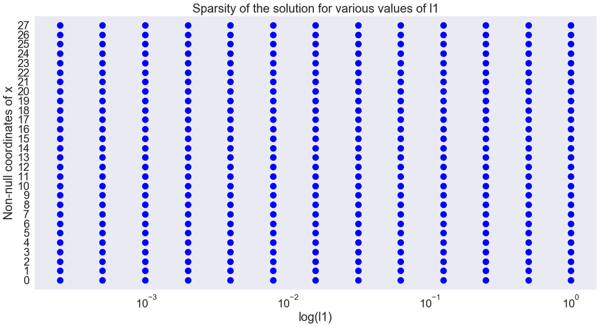

```python
from lib.visuals import l1_regularization_plot

clf = lambda l1: LogisticRegression(solver='gd', l1=l1, l2=0.1, max_iter=1000)

l1_regularization_plot(clf, A_train, b_train)
```

**Question:** The following cell will plot the value of the coordinates of the solution for various values of $l_2$.

- Interpret the plot and explain what can $L_2$ regularization be used for.

> **Answer:** Here, if $l_2$ the regularization coeficient is zero then you can imagine we get back OLS. However, if $l_2$ is very large then it will add too much weight and it will lead to under-fitting. Having said that it’s important how $l_2$ is chosen. This technique works very well to avoid over-fitting issue.

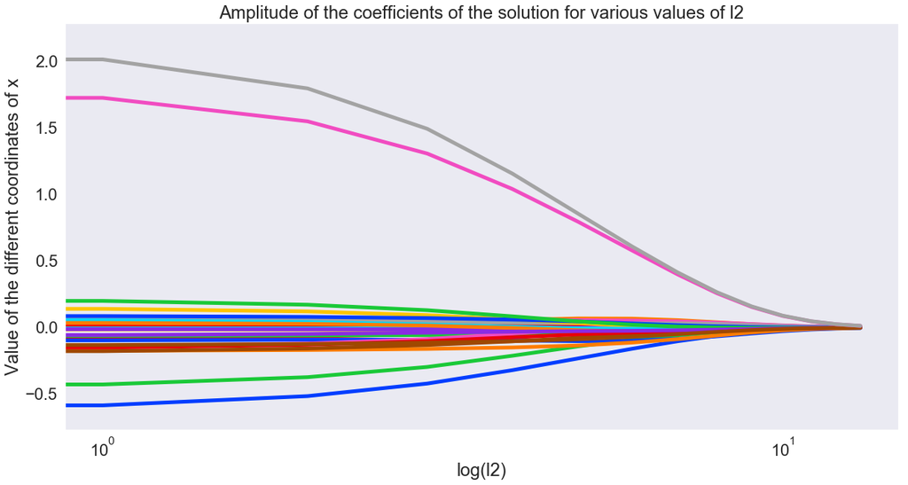

```python
from lib.visuals import l2_regularization_plot

clf = lambda l2: LogisticRegression(solver='gd', l1=0.01, l2=l2, max_iter=1000)

l2_regularization_plot(clf, A_train, b_train)
```

# V. Further development

We expect that you go beyond the lab's questions and that you develop certain aspects of your work, depending on your personal interests and skills, for instance:

- Implementations and numerical tests (further developments, more experiments, etc.)
- Applications in learning or statistics (interpretation of some results, other models, other datasets, etc.)
- Theoretical or mathematical questions (convergence proofs, convergence rates, advanced versions of an algorithm, theoretical analysis of special cases, etc.)

**Keyword ideas**: standard or stochastic Newton method, ADMM, continuation methods, tests on large scale datasets, intuition behind variance reduction, catalyst...

```python
def SNM(x0, grad, prox, max_iter, n, L, mu):
    #Standard Newton method

    epsilon  = 1/(L+mu)
    x         = x0
    x_tab     = np.copy(x)
    for k in range(1, max_iter + 1):

        if np.abs(f(x)) < epsilon:
            return x, x_tab

        grad = grad(x, i=None)

        if grad == 0:
            print('Zero derivative. No solution found.')
            return None

        x = x - f(x)/grad

        x_tab = np.vstack((x_tab, x))

    print('No solution found.')
    return None

def SSNM(x0, grad, prox, max_iter, n, L, mu):
    #Stochastic Newton method
    epsilon  = 1/(L+mu)
    x         = x0
    x_tab     = np.copy(x)
    for k in range(1, max_iter + 1):

        if np.abs(f(x)) < epsilon:
            return x, x_tab
        for i in range(1, n):
            grad += grad(x, i)
        grad = grad/n
        if grad == 0:
            print('Zero derivative. No solution found.')
            return None

        x = x - f(x)/grad

        x_tab = np.vstack((x_tab, x))

    print('No solution found.')
    return None
```

```python
def ADMM(x0, grad, prox, max_iter, n, L, mu):

    x = x0
    z = x0
    u = x0
    x_tab = np.copy(x)


    for k in range(1, max_iter + 1):
        x = prox((z-u), self.l1)
        z = prox((x+u), self.l1)
        u = u + x + z

    x_tab = np.vstack((x_tab, x))

    return x, z, u, x_tab
```